# Using fitness-trackers to predict how well an activity was performed

Stepan Kuzmin

# Question

Using devices such as Jawbone Up, Nike FuelBand, and Fitbit it is now possible to collect a large amount of data about personal activity relatively inexpensively. These type of devices are part of the quantified self movement – a group of enthusiasts who take measurements about themselves regularly to improve their health, to find patterns in their behavior, or because they are tech geeks. One thing that people regularly do is quantify *how much* of a particular activity they do, but they rarely quantify *how well* they do it.

**The goal of this project is to predict the manner in which 6 participants did the barbell lifts using data from their accelerometers on the belt, forearm, arm, and dumbell.**

# Input data

This project uses [Human Activity Recognition Weight Lifting Exercises dataset](http://groupware.les.inf.puc-rio.br/har). Six young health participants were asked to perform one set of 10 repetitions of the Unilateral Dumbbell Biceps Curl in five different fashions: exactly according to the specification (Class A), throwing the elbows to the front (Class B), lifting the dumbbell only halfway (Class C), lowering the dumbbell only halfway (Class D) and throwing the hips to the front (Class E).

```r
library(dplyr)
library(caret)
library(rpart)
library(rattle)
library(randomForest)
```

```r
data <- read.csv(url("https://d396qusza40orc.cloudfront.net/predmachlearn/pml-training.csv"),
                 na.strings=c("NA", "#DIV/0!", ""))
data <- tbl_df(data)
dim(data)
```

```
## [1] 19622   160
```

Remove first 5 columns, that not make any intuitive sense, columns that contains mostly NA’s and zero- or near-zero predictors

```r
newData <- data %>% select(-c((1:5), which(colMeans(is.na(.)) > 0.95), nearZeroVar(data)))
```

Select numeric columns

```r
numericData <- newData %>% select(which(sapply(., is.numeric)))
```

Impute missing values using `knnImpute`

```r
preprocessedData <- preProcess(numericData, method=c('knnImpute', 'center', 'scale'))
numericData <- predict(preprocessedData, numericData)
processedData <- full_join(newData, numericData)
```

Remove highly correlated variables and all observations with missing predicting variable

```r
cleanData <- processedData %>% select(-findCorrelation(cor(numericData))) %>% filter(!is.na(classe))
dim(cleanData)
```

```
## [1] 19622    47
```

```r
sum(is.na(cleanData$classe))
```

```
## [1] 0
```

Create cross validation set

```r
set.seed(123456)
inTrain <- createDataPartition(y=cleanData$classe, p=0.75, list=F)
training <- cleanData[inTrain, ]
testing <- cleanData[-inTrain, ]
dim(training)
```

```
## [1] 14718    47
```

# Algorithm

Use a random forest model, for its accuracy and acceptable performance. Fit the model on `training` dataset, and instruct the `train` function to use 3-fold cross-validation to select optimal tuning parameters for the model.

```r
fitControl <- trainControl(method="cv", number=3, verboseIter=F)
modFit <- train(classe ~ ., data=training, allowParallel=T, trControl=fitControl, method="rf")
```

```r
modFit
```

```
## Random Forest
##
## 14718 samples
##    46 predictor
##     5 classes: 'A', 'B', 'C', 'D', 'E'
##
## No pre-processing
## Resampling: Cross-Validated (3 fold)
## Summary of sample sizes: 9812, 9811, 9813
## Resampling results across tuning parameters:
##
##   mtry  Accuracy   Kappa
##    2    0.9918469  0.9896865
##   24    0.9963311  0.9953595
##   46    0.9915070  0.9892583
##
## Accuracy was used to select the optimal model using  the largest value.
## The final value used for the model was mtry = 24.
```

```r
confusionMatrix(testing$classe, predict(modFit, testing))
```

```
## Confusion Matrix and Statistics
##
##           Reference
## Prediction    A    B    C    D    E
##          A 1395    0    0    0    0
##          B    1  946    2    0    0
##          C    0    2  853    0    0
##          D    0    0    2  802    0
##          E    0    0    0    0  901
##
## Overall Statistics
##
##                Accuracy : 0.9986
##                  95% CI : (0.9971, 0.9994)
##     No Information Rate : 0.2847
##     P-Value [Acc > NIR] : < 2.2e-16
##
##                   Kappa : 0.9982
##  Mcnemar's Test P-Value : NA
##
## Statistics by Class:
##
##                      Class: A Class: B Class: C Class: D Class: E
## Sensitivity            0.9993   0.9979   0.9953   1.0000   1.0000
## Specificity            1.0000   0.9992   0.9995   0.9995   1.0000
## Pos Pred Value         1.0000   0.9968   0.9977   0.9975   1.0000
## Neg Pred Value         0.9997   0.9995   0.9990   1.0000   1.0000
## Prevalence             0.2847   0.1933   0.1748   0.1635   0.1837
## Detection Rate         0.2845   0.1929   0.1739   0.1635   0.1837
## Detection Prevalence   0.2845   0.1935   0.1743   0.1639   0.1837
## Balanced Accuracy      0.9996   0.9986   0.9974   0.9998   1.0000
```

The overall accuracy for random forest model is **0.998** what is pretty accurate.

Use classification tree model for its interpretability.

```r
modFit2 <- train(classe ~ ., data=training, method="rpart")
```

```r
modFit2
```

```
## CART
##
## 14718 samples
##    46 predictor
##     5 classes: 'A', 'B', 'C', 'D', 'E'
##
## No pre-processing
## Resampling: Bootstrapped (25 reps)
## Summary of sample sizes: 14718, 14718, 14718, 14718, 14718, 14718, ...
## Resampling results across tuning parameters:
##
##   cp          Accuracy   Kappa
##   0.03360866  0.5440393  0.42267649
##   0.03830817  0.5004227  0.35497765
##   0.06697997  0.3454716  0.09969054
##
## Accuracy was used to select the optimal model using  the largest value.
## The final value used for the model was cp = 0.03360866.
```

```r
confusionMatrix(testing$classe, predict(modFit2, testing))
```

```
## Confusion Matrix and Statistics
##
##           Reference
## Prediction    A    B    C    D    E
##          A 1175   32  187    0    1
##          B  154  330  464    0    1
##          C   18   27  808    0    2
##          D   78  152  511    0   63
##          E   62  172  395    0  272
##
## Overall Statistics
##
##                Accuracy : 0.5271
##                  95% CI : (0.513, 0.5412)
##     No Information Rate : 0.4823
##     P-Value [Acc > NIR] : 1.8e-10
##
##                   Kappa : 0.4005
##  Mcnemar's Test P-Value : < 2e-16
##
## Statistics by Class:
##
##                      Class: A Class: B Class: C Class: D Class: E
## Sensitivity            0.7902  0.46283   0.3416       NA  0.80236
## Specificity            0.9356  0.85230   0.9815   0.8361  0.86221
## Pos Pred Value         0.8423  0.34773   0.9450       NA  0.30189
## Neg Pred Value         0.9111  0.90316   0.6155       NA  0.98326
## Prevalence             0.3032  0.14539   0.4823   0.0000  0.06913
## Detection Rate         0.2396  0.06729   0.1648   0.0000  0.05546
## Detection Prevalence   0.2845  0.19352   0.1743   0.1639  0.18373
## Balanced Accuracy      0.8629  0.65757   0.6616       NA  0.83229
```

The overall accuracy for classification tree model is **0.527** what is less accurate than random forest model.

[figure not shown]

```r
fancyRpartPlot(modFit2$finalModel)
```

# Cross validation

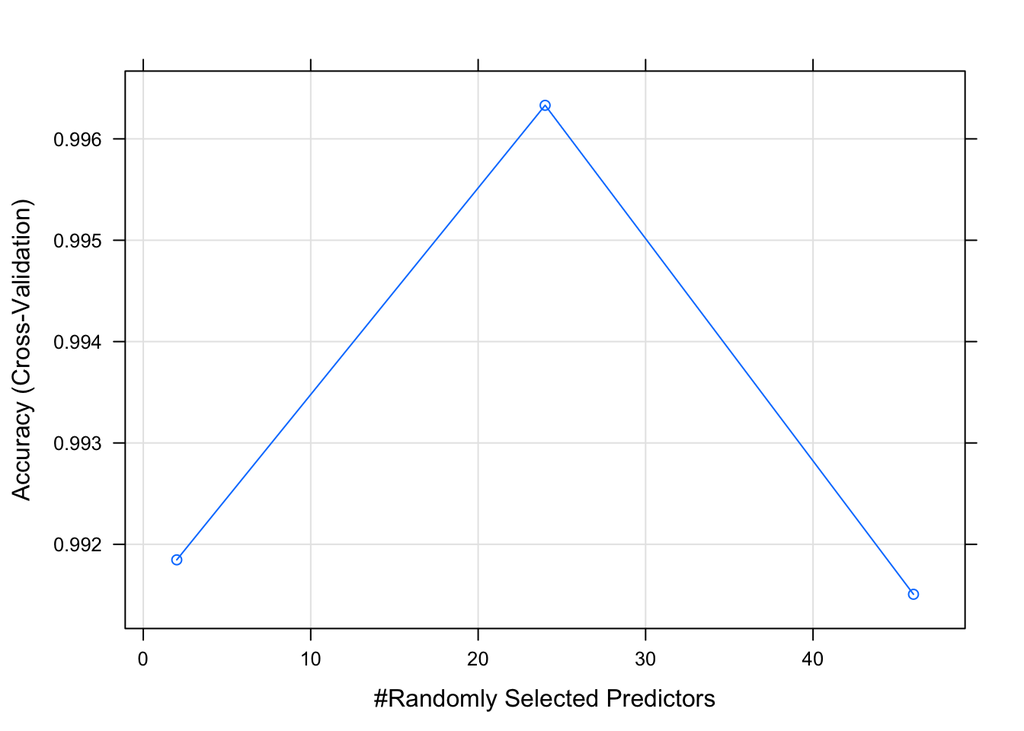

```r
plot(modFit)
```

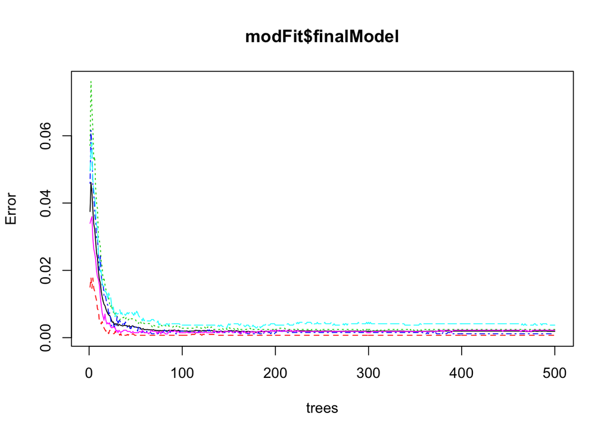

```r
plot(modFit$finalModel)
```

The final model plot tells that the overall error converge at around 100 trees, so it is possible to speed up our algo by tuning the number of trees.

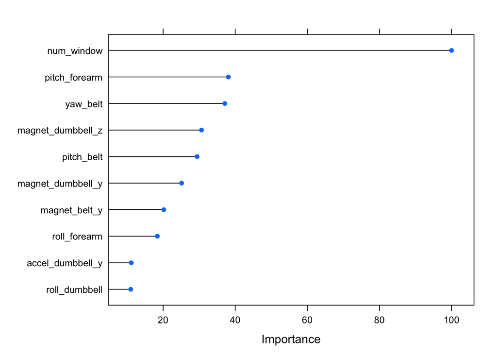

```r
plot(varImp(modFit), top = 10)
```

Top ten important variables

# Evaluation

Predict testing dataset using random forest model

```r
testingData <- read.csv(url("https://d396qusza40orc.cloudfront.net/predmachlearn/pml-testing.csv"),
                        na.strings=c("NA", "#DIV/0!", ""))
testingData$classe <- NA
cleanTestingData <- testingData %>% select(match(colnames(cleanData), names(.)))
```

```r
print(predict(modFit, newdata=cleanTestingData))
```

```
##  [1] B A B A A E D B A A B C B A E E A B B B
## Levels: A B C D E
```